# Risk Factor Analysis

## Outcome Variable

**Outcome Variable:** ever_co

## Predictor Variables

**Intervention Variable:** exclfeed6

**Adjustment Set:**

- arm
- sex
- W_mage
- meducyrs
- feducyrs
- hhwealth_quart
- hfoodsec
- W_mhtcm
- vagbrth
- W_gagebrth
- W_birthwt
- W_birthlen
- W_nrooms
- W_nchldlt5
- month
- brthmon
- W_parity
- impfloor
- impsan
- safeh20
- delta_W_mage
- delta_meducyrs
- delta_feducyrs
- delta_hhwealth_quart
- delta_hfoodsec
- delta_W_mhtcm
- delta_vagbrth
- delta_W_gagebrth
- delta_W_birthwt
- delta_W_birthlen
- delta_W_nrooms
- delta_W_nchldlt5
- delta_month
- delta_brthmon
- delta_W_parity
- delta_impfloor
- delta_impsan
- delta_safeh20

## Stratifying Variables

The analysis was stratified on these variable(s):

- agecat
- studyid
- country

## Data Summary

| agecat | studyid | country | exclfeed6 | ever_co | n_cell | n |
| --- | --- | --- | --- | --- | --- | --- |
| 0-24 months | ki0047075b-MAL-ED | BANGLADESH | 1 | 0 | 44 | 238 |
| 0-24 months | ki0047075b-MAL-ED | BANGLADESH | 1 | 1 | 14 | 238 |
| 0-24 months | ki0047075b-MAL-ED | BANGLADESH | 0 | 0 | 155 | 238 |
| 0-24 months | ki0047075b-MAL-ED | BANGLADESH | 0 | 1 | 25 | 238 |
| 0-24 months | ki0047075b-MAL-ED | BRAZIL | 1 | 0 | 17 | 212 |
| 0-24 months | ki0047075b-MAL-ED | BRAZIL | 1 | 1 | 0 | 212 |
| 0-24 months | ki0047075b-MAL-ED | BRAZIL | 0 | 0 | 193 | 212 |
| 0-24 months | ki0047075b-MAL-ED | BRAZIL | 0 | 1 | 2 | 212 |
| 0-24 months | ki0047075b-MAL-ED | INDIA | 1 | 0 | 6 | 234 |
| 0-24 months | ki0047075b-MAL-ED | INDIA | 1 | 1 | 0 | 234 |
| 0-24 months | ki0047075b-MAL-ED | INDIA | 0 | 0 | 176 | 234 |
| 0-24 months | ki0047075b-MAL-ED | INDIA | 0 | 1 | 52 | 234 |
| 0-24 months | ki0047075b-MAL-ED | NEPAL | 1 | 0 | 14 | 235 |
| 0-24 months | ki0047075b-MAL-ED | NEPAL | 1 | 1 | 1 | 235 |
| 0-24 months | ki0047075b-MAL-ED | NEPAL | 0 | 0 | 200 | 235 |
| 0-24 months | ki0047075b-MAL-ED | NEPAL | 0 | 1 | 20 | 235 |
| 0-24 months | ki0047075b-MAL-ED | PERU | 1 | 0 | 11 | 270 |
| 0-24 months | ki0047075b-MAL-ED | PERU | 1 | 1 | 0 | 270 |
| 0-24 months | ki0047075b-MAL-ED | PERU | 0 | 0 | 250 | 270 |
| 0-24 months | ki0047075b-MAL-ED | PERU | 0 | 1 | 9 | 270 |
| 0-24 months | ki0047075b-MAL-ED | SOUTH AFRICA | 1 | 0 | 0 | 248 |
| 0-24 months | ki0047075b-MAL-ED | SOUTH AFRICA | 1 | 1 | 0 | 248 |
| 0-24 months | ki0047075b-MAL-ED | SOUTH AFRICA | 0 | 0 | 227 | 248 |
| 0-24 months | ki0047075b-MAL-ED | SOUTH AFRICA | 0 | 1 | 21 | 248 |
| 0-24 months | ki0047075b-MAL-ED | TANZANIA, UNITED REPUBLIC OF | 1 | 0 | 1 | 248 |
| 0-24 months | ki0047075b-MAL-ED | TANZANIA, UNITED REPUBLIC OF | 1 | 1 | 0 | 248 |
| 0-24 months | ki0047075b-MAL-ED | TANZANIA, UNITED REPUBLIC OF | 0 | 0 | 224 | 248 |
| 0-24 months | ki0047075b-MAL-ED | TANZANIA, UNITED REPUBLIC OF | 0 | 1 | 23 | 248 |
| 0-24 months | ki1000108-CMC-V-BCS-2002 | INDIA | 1 | 0 | 15 | 19 |
| 0-24 months | ki1000108-CMC-V-BCS-2002 | INDIA | 1 | 1 | 4 | 19 |

[output cut: 186 more lines]

The following strata were considered:

- agecat: 0-24 months, studyid: ki0047075b-MAL-ED, country: BANGLADESH
- agecat: 0-24 months, studyid: ki0047075b-MAL-ED, country: BRAZIL
- agecat: 0-24 months, studyid: ki0047075b-MAL-ED, country: INDIA
- agecat: 0-24 months, studyid: ki0047075b-MAL-ED, country: NEPAL
- agecat: 0-24 months, studyid: ki0047075b-MAL-ED, country: PERU
- agecat: 0-24 months, studyid: ki0047075b-MAL-ED, country: SOUTH AFRICA
- agecat: 0-24 months, studyid: ki0047075b-MAL-ED, country: TANZANIA, UNITED REPUBLIC OF
- agecat: 0-24 months, studyid: ki1000108-CMC-V-BCS-2002, country: INDIA
- agecat: 0-24 months, studyid: ki1000108-IRC, country: INDIA
- agecat: 0-24 months, studyid: ki1000109-EE, country: PAKISTAN
- agecat: 0-24 months, studyid: ki1000304b-SAS-CompFeed, country: INDIA
- agecat: 0-24 months, studyid: ki1000304b-SAS-FoodSuppl, country: INDIA
- agecat: 0-24 months, studyid: ki1017093b-PROVIDE, country: BANGLADESH
- agecat: 0-24 months, studyid: ki1101329-Keneba, country: GAMBIA
- agecat: 0-24 months, studyid: ki1113344-GMS-Nepal, country: NEPAL
- agecat: 0-24 months, studyid: ki1148112-LCNI-5, country: MALAWI
- agecat: 0-24 months, studyid: kiGH5241-JiVitA-3, country: BANGLADESH
- agecat: 0-24 months, studyid: kiGH5241-JiVitA-4, country: BANGLADESH
- agecat: 0-6 months, studyid: ki0047075b-MAL-ED, country: BANGLADESH
- agecat: 0-6 months, studyid: ki0047075b-MAL-ED, country: BRAZIL
- agecat: 0-6 months, studyid: ki0047075b-MAL-ED, country: INDIA
- agecat: 0-6 months, studyid: ki0047075b-MAL-ED, country: NEPAL
- agecat: 0-6 months, studyid: ki0047075b-MAL-ED, country: PERU
- agecat: 0-6 months, studyid: ki0047075b-MAL-ED, country: SOUTH AFRICA
- agecat: 0-6 months, studyid: ki0047075b-MAL-ED, country: TANZANIA, UNITED REPUBLIC OF
- agecat: 0-6 months, studyid: ki1000108-CMC-V-BCS-2002, country: INDIA
- agecat: 0-6 months, studyid: ki1000108-IRC, country: INDIA
- agecat: 0-6 months, studyid: ki1000109-EE, country: PAKISTAN
- agecat: 0-6 months, studyid: ki1000304b-SAS-CompFeed, country: INDIA
- agecat: 0-6 months, studyid: ki1000304b-SAS-FoodSuppl, country: INDIA
- agecat: 0-6 months, studyid: ki1017093b-PROVIDE, country: BANGLADESH
- agecat: 0-6 months, studyid: ki1101329-Keneba, country: GAMBIA
- agecat: 0-6 months, studyid: ki1113344-GMS-Nepal, country: NEPAL
- agecat: 0-6 months, studyid: ki1148112-LCNI-5, country: MALAWI
- agecat: 0-6 months, studyid: kiGH5241-JiVitA-3, country: BANGLADESH
- agecat: 0-6 months, studyid: kiGH5241-JiVitA-4, country: BANGLADESH
- agecat: 6-24 months, studyid: ki0047075b-MAL-ED, country: BANGLADESH
- agecat: 6-24 months, studyid: ki0047075b-MAL-ED, country: BRAZIL
- agecat: 6-24 months, studyid: ki0047075b-MAL-ED, country: INDIA
- agecat: 6-24 months, studyid: ki0047075b-MAL-ED, country: NEPAL
- agecat: 6-24 months, studyid: ki0047075b-MAL-ED, country: PERU
- agecat: 6-24 months, studyid: ki0047075b-MAL-ED, country: SOUTH AFRICA
- agecat: 6-24 months, studyid: ki0047075b-MAL-ED, country: TANZANIA, UNITED REPUBLIC OF
- agecat: 6-24 months, studyid: ki1000108-CMC-V-BCS-2002, country: INDIA
- agecat: 6-24 months, studyid: ki1000108-IRC, country: INDIA
- agecat: 6-24 months, studyid: ki1000109-EE, country: PAKISTAN
- agecat: 6-24 months, studyid: ki1000304b-SAS-CompFeed, country: INDIA
- agecat: 6-24 months, studyid: ki1000304b-SAS-FoodSuppl, country: INDIA
- agecat: 6-24 months, studyid: ki1017093b-PROVIDE, country: BANGLADESH
- agecat: 6-24 months, studyid: ki1101329-Keneba, country: GAMBIA
- agecat: 6-24 months, studyid: ki1113344-GMS-Nepal, country: NEPAL
- agecat: 6-24 months, studyid: ki1148112-LCNI-5, country: MALAWI
- agecat: 6-24 months, studyid: kiGH5241-JiVitA-3, country: BANGLADESH
- agecat: 6-24 months, studyid: kiGH5241-JiVitA-4, country: BANGLADESH

### Dropped Strata

Some strata were dropped due to rare outcomes:

- agecat: 0-24 months, studyid: ki0047075b-MAL-ED, country: BRAZIL
- agecat: 0-24 months, studyid: ki0047075b-MAL-ED, country: INDIA
- agecat: 0-24 months, studyid: ki0047075b-MAL-ED, country: NEPAL
- agecat: 0-24 months, studyid: ki0047075b-MAL-ED, country: PERU
- agecat: 0-24 months, studyid: ki0047075b-MAL-ED, country: SOUTH AFRICA
- agecat: 0-24 months, studyid: ki0047075b-MAL-ED, country: TANZANIA, UNITED REPUBLIC OF
- agecat: 0-24 months, studyid: ki1000108-CMC-V-BCS-2002, country: INDIA
- agecat: 0-24 months, studyid: ki1000108-IRC, country: INDIA
- agecat: 0-24 months, studyid: ki1000304b-SAS-FoodSuppl, country: INDIA
- agecat: 0-24 months, studyid: ki1148112-LCNI-5, country: MALAWI
- agecat: 0-6 months, studyid: ki0047075b-MAL-ED, country: BANGLADESH
- agecat: 0-6 months, studyid: ki0047075b-MAL-ED, country: BRAZIL
- agecat: 0-6 months, studyid: ki0047075b-MAL-ED, country: INDIA
- agecat: 0-6 months, studyid: ki0047075b-MAL-ED, country: NEPAL
- agecat: 0-6 months, studyid: ki0047075b-MAL-ED, country: PERU
- agecat: 0-6 months, studyid: ki0047075b-MAL-ED, country: SOUTH AFRICA
- agecat: 0-6 months, studyid: ki0047075b-MAL-ED, country: TANZANIA, UNITED REPUBLIC OF
- agecat: 0-6 months, studyid: ki1000108-CMC-V-BCS-2002, country: INDIA
- agecat: 0-6 months, studyid: ki1000108-IRC, country: INDIA
- agecat: 0-6 months, studyid: ki1000304b-SAS-CompFeed, country: INDIA
- agecat: 0-6 months, studyid: ki1000304b-SAS-FoodSuppl, country: INDIA
- agecat: 0-6 months, studyid: ki1017093b-PROVIDE, country: BANGLADESH
- agecat: 0-6 months, studyid: ki1148112-LCNI-5, country: MALAWI
- agecat: 6-24 months, studyid: ki0047075b-MAL-ED, country: BRAZIL
- agecat: 6-24 months, studyid: ki0047075b-MAL-ED, country: INDIA
- agecat: 6-24 months, studyid: ki0047075b-MAL-ED, country: NEPAL
- agecat: 6-24 months, studyid: ki0047075b-MAL-ED, country: PERU
- agecat: 6-24 months, studyid: ki0047075b-MAL-ED, country: SOUTH AFRICA
- agecat: 6-24 months, studyid: ki0047075b-MAL-ED, country: TANZANIA, UNITED REPUBLIC OF
- agecat: 6-24 months, studyid: ki1000108-CMC-V-BCS-2002, country: INDIA
- agecat: 6-24 months, studyid: ki1000108-IRC, country: INDIA
- agecat: 6-24 months, studyid: ki1000304b-SAS-FoodSuppl, country: INDIA
- agecat: 6-24 months, studyid: ki1148112-LCNI-5, country: MALAWI

## Methods Detail

We’re interested in the causal parameters $E[Y_a]$ for all values of $a \in \mathcal{A}$. These parameters represent the mean outcome if, possibly contrary to fact, we intervened to set all units to have $A=a$. Under the randomization and positivity assumptions, these are identified by the statistical parameters $\psi_a=E_W[E_{Y|A,W}(Y|A=a,W)]$. In addition, we’re interested in the mean of $Y$, $E[Y]$ under no intervention (the observed mean). We will estimate these parameters by using SuperLearner to fit the relevant likelihood factors – $E_{Y|A,W}(Y|A=a,W)$ and $p(A=a|W)$, and then updating our likelihood fit using a joint TMLE.

For unadjusted analyses ($W=\{\}$), initial likelihoods were estimated using Lrnr_glm to estimate the simple $E(Y|A)$ and Lrnr_mean to estimate $p(A)$. For adjusted analyses, a small library containing Lrnr_glmnet, Lrnr_xgboost, and Lrnr_mean was used.

Having estimated these parameters, we will then use the delta method to estimate relative risks and attributable risks relative to a prespecified baseline level of $A$.

# Results Detail

## Results Plots

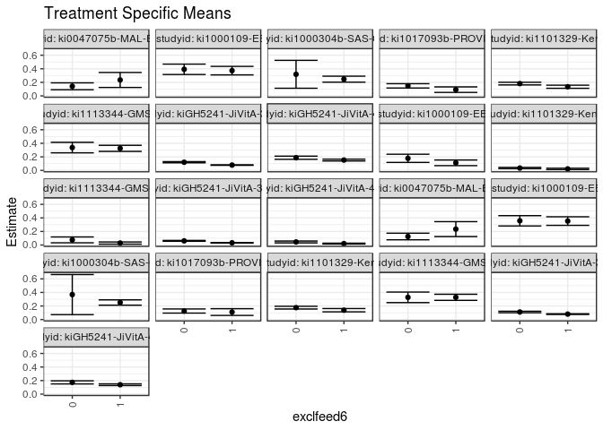

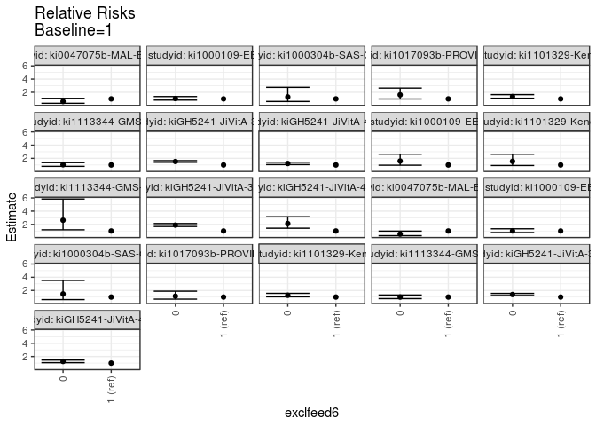

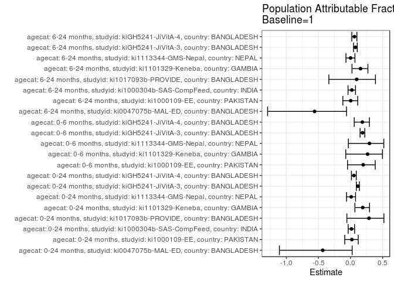

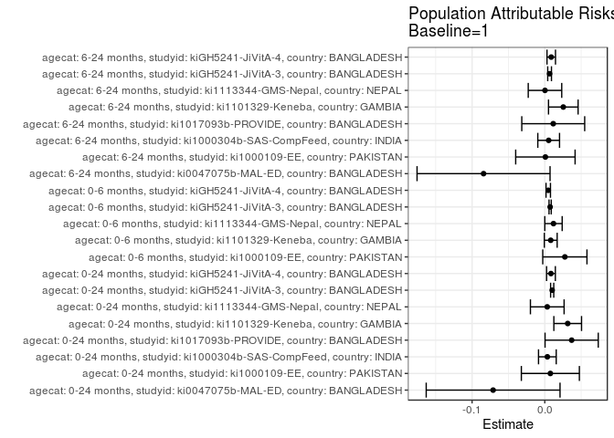

## Results Table

### Parameter: TSM

| agecat | studyid | country | intervention_level | baseline_level | estimate | ci_lower | ci_upper |
| --- | --- | --- | --- | --- | --- | --- | --- |
| 0-24 months | ki0047075b-MAL-ED | BANGLADESH | 1 | NA | 0.2349183 | 0.1243321 | 0.3455046 |
| 0-24 months | ki0047075b-MAL-ED | BANGLADESH | 0 | NA | 0.1413378 | 0.0906956 | 0.1919799 |
| 0-24 months | ki1000109-EE | PAKISTAN | 1 | NA | 0.3722725 | 0.3096219 | 0.4349231 |
| 0-24 months | ki1000109-EE | PAKISTAN | 0 | NA | 0.3918729 | 0.3153902 | 0.4683557 |
| 0-24 months | ki1000304b-SAS-CompFeed | INDIA | 1 | NA | 0.2464455 | 0.2022875 | 0.2906035 |
| 0-24 months | ki1000304b-SAS-CompFeed | INDIA | 0 | NA | 0.3181818 | 0.1124254 | 0.5239382 |
| 0-24 months | ki1017093b-PROVIDE | BANGLADESH | 1 | NA | 0.0916075 | 0.0507970 | 0.1324180 |
| 0-24 months | ki1017093b-PROVIDE | BANGLADESH | 0 | NA | 0.1478278 | 0.1162350 | 0.1794206 |
| 0-24 months | ki1101329-Keneba | GAMBIA | 1 | NA | 0.1344767 | 0.1116368 | 0.1573166 |
| 0-24 months | ki1101329-Keneba | GAMBIA | 0 | NA | 0.1811888 | 0.1613939 | 0.2009837 |
| 0-24 months | ki1113344-GMS-Nepal | NEPAL | 1 | NA | 0.3257973 | 0.2809532 | 0.3706414 |
| 0-24 months | ki1113344-GMS-Nepal | NEPAL | 0 | NA | 0.3373370 | 0.2598536 | 0.4148205 |
| 0-24 months | kiGH5241-JiVitA-3 | BANGLADESH | 1 | NA | 0.0791744 | 0.0750587 | 0.0832900 |
| 0-24 months | kiGH5241-JiVitA-3 | BANGLADESH | 0 | NA | 0.1206083 | 0.1119797 | 0.1292368 |
| 0-24 months | kiGH5241-JiVitA-4 | BANGLADESH | 1 | NA | 0.1530806 | 0.1397639 | 0.1663972 |
| 0-24 months | kiGH5241-JiVitA-4 | BANGLADESH | 0 | NA | 0.1873229 | 0.1639641 | 0.2106817 |
| 0-6 months | ki1000109-EE | PAKISTAN | 1 | NA | 0.1122365 | 0.0705662 | 0.1539068 |
| 0-6 months | ki1000109-EE | PAKISTAN | 0 | NA | 0.1787259 | 0.1181176 | 0.2393341 |
| 0-6 months | ki1101329-Keneba | GAMBIA | 1 | NA | 0.0226837 | 0.0125470 | 0.0328204 |
| 0-6 months | ki1101329-Keneba | GAMBIA | 0 | NA | 0.0351829 | 0.0255690 | 0.0447968 |
| 0-6 months | ki1113344-GMS-Nepal | NEPAL | 1 | NA | 0.0287323 | 0.0127498 | 0.0447148 |
| 0-6 months | ki1113344-GMS-Nepal | NEPAL | 0 | NA | 0.0756059 | 0.0324680 | 0.1187438 |
| 0-6 months | kiGH5241-JiVitA-3 | BANGLADESH | 1 | NA | 0.0322535 | 0.0297779 | 0.0347291 |
| 0-6 months | kiGH5241-JiVitA-3 | BANGLADESH | 0 | NA | 0.0610263 | 0.0549574 | 0.0670953 |
| 0-6 months | kiGH5241-JiVitA-4 | BANGLADESH | 1 | NA | 0.0211385 | 0.0153396 | 0.0269375 |
| 0-6 months | kiGH5241-JiVitA-4 | BANGLADESH | 0 | NA | 0.0447986 | 0.0311619 | 0.0584352 |
| 6-24 months | ki0047075b-MAL-ED | BANGLADESH | 1 | NA | 0.2344245 | 0.1244590 | 0.3443900 |
| 6-24 months | ki0047075b-MAL-ED | BANGLADESH | 0 | NA | 0.1253658 | 0.0763559 | 0.1743757 |
| 6-24 months | ki1000109-EE | PAKISTAN | 1 | NA | 0.3530520 | 0.2898781 | 0.4162260 |
| 6-24 months | ki1000109-EE | PAKISTAN | 0 | NA | 0.3568874 | 0.2810722 | 0.4327026 |
| 6-24 months | ki1000304b-SAS-CompFeed | INDIA | 1 | NA | 0.2512563 | 0.2120897 | 0.2904228 |
| 6-24 months | ki1000304b-SAS-CompFeed | INDIA | 0 | NA | 0.3684211 | 0.0727072 | 0.6641349 |
| 6-24 months | ki1017093b-PROVIDE | BANGLADESH | 1 | NA | 0.1105214 | 0.0608550 | 0.1601877 |
| 6-24 months | ki1017093b-PROVIDE | BANGLADESH | 0 | NA | 0.1256077 | 0.0953111 | 0.1559044 |
| 6-24 months | ki1101329-Keneba | GAMBIA | 1 | NA | 0.1381704 | 0.1138311 | 0.1625097 |
| 6-24 months | ki1101329-Keneba | GAMBIA | 0 | NA | 0.1757975 | 0.1558316 | 0.1957634 |
| 6-24 months | ki1113344-GMS-Nepal | NEPAL | 1 | NA | 0.3282691 | 0.2830532 | 0.3734851 |
| 6-24 months | ki1113344-GMS-Nepal | NEPAL | 0 | NA | 0.3279464 | 0.2500971 | 0.4057956 |
| 6-24 months | kiGH5241-JiVitA-3 | BANGLADESH | 1 | NA | 0.0805031 | 0.0755129 | 0.0854934 |
| 6-24 months | kiGH5241-JiVitA-3 | BANGLADESH | 0 | NA | 0.1114275 | 0.1005609 | 0.1222941 |
| 6-24 months | kiGH5241-JiVitA-4 | BANGLADESH | 1 | NA | 0.1386439 | 0.1261874 | 0.1511004 |
| 6-24 months | kiGH5241-JiVitA-4 | BANGLADESH | 0 | NA | 0.1733578 | 0.1502981 | 0.1964176 |

### Parameter: E(Y)

| agecat | studyid | country | intervention_level | baseline_level | estimate | ci_lower | ci_upper |
| --- | --- | --- | --- | --- | --- | --- | --- |
| 0-24 months | ki0047075b-MAL-ED | BANGLADESH | NA | NA | 0.1638655 | 0.1167401 | 0.2109910 |
| 0-24 months | ki1000109-EE | PAKISTAN | NA | NA | 0.3799472 | 0.3310169 | 0.4288776 |
| 0-24 months | ki1000304b-SAS-CompFeed | INDIA | NA | NA | 0.2500000 | 0.2118239 | 0.2881761 |
| 0-24 months | ki1017093b-PROVIDE | BANGLADESH | NA | NA | 0.1285714 | 0.1037574 | 0.1533855 |
| 0-24 months | ki1101329-Keneba | GAMBIA | NA | NA | 0.1659955 | 0.1505665 | 0.1814246 |
| 0-24 months | ki1113344-GMS-Nepal | NEPAL | NA | NA | 0.3292035 | 0.2904210 | 0.3679861 |
| 0-24 months | kiGH5241-JiVitA-3 | BANGLADESH | NA | NA | 0.0893606 | 0.0854348 | 0.0932864 |
| 0-24 months | kiGH5241-JiVitA-4 | BANGLADESH | NA | NA | 0.1615841 | 0.1496375 | 0.1735306 |
| 0-6 months | ki1000109-EE | PAKISTAN | NA | NA | 0.1398417 | 0.1048786 | 0.1748048 |
| 0-6 months | ki1101329-Keneba | GAMBIA | NA | NA | 0.0308725 | 0.0236998 | 0.0380452 |
| 0-6 months | ki1113344-GMS-Nepal | NEPAL | NA | NA | 0.0407080 | 0.0243991 | 0.0570168 |
| 0-6 months | kiGH5241-JiVitA-3 | BANGLADESH | NA | NA | 0.0396219 | 0.0371297 | 0.0421141 |
| 0-6 months | kiGH5241-JiVitA-4 | BANGLADESH | NA | NA | 0.0259078 | 0.0204779 | 0.0313377 |
| 6-24 months | ki0047075b-MAL-ED | BANGLADESH | NA | NA | 0.1502146 | 0.1042403 | 0.1961889 |
| 6-24 months | ki1000109-EE | PAKISTAN | NA | NA | 0.3538874 | 0.3052956 | 0.4024792 |
| 6-24 months | ki1000304b-SAS-CompFeed | INDIA | NA | NA | 0.2565947 | 0.2209578 | 0.2922316 |
| 6-24 months | ki1017093b-PROVIDE | BANGLADESH | NA | NA | 0.1221498 | 0.0962275 | 0.1480722 |
| 6-24 months | ki1101329-Keneba | GAMBIA | NA | NA | 0.1636364 | 0.1477722 | 0.1795005 |
| 6-24 months | ki1113344-GMS-Nepal | NEPAL | NA | NA | 0.3285458 | 0.2895051 | 0.3675864 |
| 6-24 months | kiGH5241-JiVitA-3 | BANGLADESH | NA | NA | 0.0871139 | 0.0824317 | 0.0917961 |
| 6-24 months | kiGH5241-JiVitA-4 | BANGLADESH | NA | NA | 0.1475271 | 0.1364035 | 0.1586506 |

### Parameter: RR

| agecat | studyid | country | intervention_level | baseline_level | estimate | ci_lower | ci_upper |
| --- | --- | --- | --- | --- | --- | --- | --- |
| 0-24 months | ki0047075b-MAL-ED | BANGLADESH | 1 | 1 | 1.0000000 | 1.0000000 | 1.0000000 |
| 0-24 months | ki0047075b-MAL-ED | BANGLADESH | 0 | 1 | 0.6016463 | 0.3347453 | 1.0813545 |
| 0-24 months | ki1000109-EE | PAKISTAN | 1 | 1 | 1.0000000 | 1.0000000 | 1.0000000 |
| 0-24 months | ki1000109-EE | PAKISTAN | 0 | 1 | 1.0526508 | 0.8171289 | 1.3560575 |
| 0-24 months | ki1000304b-SAS-CompFeed | INDIA | 1 | 1 | 1.0000000 | 1.0000000 | 1.0000000 |
| 0-24 months | ki1000304b-SAS-CompFeed | INDIA | 0 | 1 | 1.2910839 | 0.6050646 | 2.7549084 |
| 0-24 months | ki1017093b-PROVIDE | BANGLADESH | 1 | 1 | 1.0000000 | 1.0000000 | 1.0000000 |
| 0-24 months | ki1017093b-PROVIDE | BANGLADESH | 0 | 1 | 1.6137080 | 0.9858069 | 2.6415452 |
| 0-24 months | ki1101329-Keneba | GAMBIA | 1 | 1 | 1.0000000 | 1.0000000 | 1.0000000 |
| 0-24 months | ki1101329-Keneba | GAMBIA | 0 | 1 | 1.3473620 | 1.1046073 | 1.6434658 |
| 0-24 months | ki1113344-GMS-Nepal | NEPAL | 1 | 1 | 1.0000000 | 1.0000000 | 1.0000000 |
| 0-24 months | ki1113344-GMS-Nepal | NEPAL | 0 | 1 | 1.0354200 | 0.7922433 | 1.3532391 |
| 0-24 months | kiGH5241-JiVitA-3 | BANGLADESH | 1 | 1 | 1.0000000 | 1.0000000 | 1.0000000 |
| 0-24 months | kiGH5241-JiVitA-3 | BANGLADESH | 0 | 1 | 1.5233246 | 1.4019772 | 1.6551753 |
| 0-24 months | kiGH5241-JiVitA-4 | BANGLADESH | 1 | 1 | 1.0000000 | 1.0000000 | 1.0000000 |
| 0-24 months | kiGH5241-JiVitA-4 | BANGLADESH | 0 | 1 | 1.2236881 | 1.0565666 | 1.4172439 |
| 0-6 months | ki1000109-EE | PAKISTAN | 1 | 1 | 1.0000000 | 1.0000000 | 1.0000000 |
| 0-6 months | ki1000109-EE | PAKISTAN | 0 | 1 | 1.5924047 | 0.9635667 | 2.6316317 |
| 0-6 months | ki1101329-Keneba | GAMBIA | 1 | 1 | 1.0000000 | 1.0000000 | 1.0000000 |
| 0-6 months | ki1101329-Keneba | GAMBIA | 0 | 1 | 1.5510227 | 0.9186097 | 2.6188176 |
| 0-6 months | ki1113344-GMS-Nepal | NEPAL | 1 | 1 | 1.0000000 | 1.0000000 | 1.0000000 |
| 0-6 months | ki1113344-GMS-Nepal | NEPAL | 0 | 1 | 2.6313912 | 1.1854794 | 5.8408603 |
| 0-6 months | kiGH5241-JiVitA-3 | BANGLADESH | 1 | 1 | 1.0000000 | 1.0000000 | 1.0000000 |
| 0-6 months | kiGH5241-JiVitA-3 | BANGLADESH | 0 | 1 | 1.8920854 | 1.6835931 | 2.1263970 |
| 0-6 months | kiGH5241-JiVitA-4 | BANGLADESH | 1 | 1 | 1.0000000 | 1.0000000 | 1.0000000 |
| 0-6 months | kiGH5241-JiVitA-4 | BANGLADESH | 0 | 1 | 2.1192863 | 1.4195160 | 3.1640183 |
| 6-24 months | ki0047075b-MAL-ED | BANGLADESH | 1 | 1 | 1.0000000 | 1.0000000 | 1.0000000 |
| 6-24 months | ki0047075b-MAL-ED | BANGLADESH | 0 | 1 | 0.5347812 | 0.2901397 | 0.9857006 |
| 6-24 months | ki1000109-EE | PAKISTAN | 1 | 1 | 1.0000000 | 1.0000000 | 1.0000000 |
| 6-24 months | ki1000109-EE | PAKISTAN | 0 | 1 | 1.0108635 | 0.7670316 | 1.3322072 |
| 6-24 months | ki1000304b-SAS-CompFeed | INDIA | 1 | 1 | 1.0000000 | 1.0000000 | 1.0000000 |
| 6-24 months | ki1000304b-SAS-CompFeed | INDIA | 0 | 1 | 1.4663158 | 0.6118309 | 3.5141768 |
| 6-24 months | ki1017093b-PROVIDE | BANGLADESH | 1 | 1 | 1.0000000 | 1.0000000 | 1.0000000 |
| 6-24 months | ki1017093b-PROVIDE | BANGLADESH | 0 | 1 | 1.1365020 | 0.6833552 | 1.8901396 |
| 6-24 months | ki1101329-Keneba | GAMBIA | 1 | 1 | 1.0000000 | 1.0000000 | 1.0000000 |
| 6-24 months | ki1101329-Keneba | GAMBIA | 0 | 1 | 1.2723237 | 1.0352687 | 1.5636593 |
| 6-24 months | ki1113344-GMS-Nepal | NEPAL | 1 | 1 | 1.0000000 | 1.0000000 | 1.0000000 |
| 6-24 months | ki1113344-GMS-Nepal | NEPAL | 0 | 1 | 0.9990167 | 0.7598943 | 1.3133857 |
| 6-24 months | kiGH5241-JiVitA-3 | BANGLADESH | 1 | 1 | 1.0000000 | 1.0000000 | 1.0000000 |
| 6-24 months | kiGH5241-JiVitA-3 | BANGLADESH | 0 | 1 | 1.3841386 | 1.2371163 | 1.5486335 |
| 6-24 months | kiGH5241-JiVitA-4 | BANGLADESH | 1 | 1 | 1.0000000 | 1.0000000 | 1.0000000 |
| 6-24 months | kiGH5241-JiVitA-4 | BANGLADESH | 0 | 1 | 1.2503821 | 1.0682641 | 1.4635475 |

### Parameter: PAR

| agecat | studyid | country | intervention_level | baseline_level | estimate | ci_lower | ci_upper |
| --- | --- | --- | --- | --- | --- | --- | --- |
| 0-24 months | ki0047075b-MAL-ED | BANGLADESH | 1 | NA | -0.0710528 | -0.1630644 | 0.0209588 |
| 0-24 months | ki1000109-EE | PAKISTAN | 1 | NA | 0.0076747 | -0.0322171 | 0.0475666 |
| 0-24 months | ki1000304b-SAS-CompFeed | INDIA | 1 | NA | 0.0035545 | -0.0086130 | 0.0157220 |
| 0-24 months | ki1017093b-PROVIDE | BANGLADESH | 1 | NA | 0.0369639 | 0.0003782 | 0.0735496 |
| 0-24 months | ki1101329-Keneba | GAMBIA | 1 | NA | 0.0315188 | 0.0124835 | 0.0505542 |
| 0-24 months | ki1113344-GMS-Nepal | NEPAL | 1 | NA | 0.0034062 | -0.0197468 | 0.0265592 |
| 0-24 months | kiGH5241-JiVitA-3 | BANGLADESH | 1 | NA | 0.0101862 | 0.0080282 | 0.0123443 |
| 0-24 months | kiGH5241-JiVitA-4 | BANGLADESH | 1 | NA | 0.0085035 | 0.0024761 | 0.0145309 |
| 0-6 months | ki1000109-EE | PAKISTAN | 1 | NA | 0.0276052 | -0.0027878 | 0.0579982 |
| 0-6 months | ki1101329-Keneba | GAMBIA | 1 | NA | 0.0081888 | -0.0006338 | 0.0170114 |
| 0-6 months | ki1113344-GMS-Nepal | NEPAL | 1 | NA | 0.0119757 | 0.0000358 | 0.0239156 |
| 0-6 months | kiGH5241-JiVitA-3 | BANGLADESH | 1 | NA | 0.0073685 | 0.0058369 | 0.0089000 |
| 0-6 months | kiGH5241-JiVitA-4 | BANGLADESH | 1 | NA | 0.0047693 | 0.0017275 | 0.0078111 |
| 6-24 months | ki0047075b-MAL-ED | BANGLADESH | 1 | NA | -0.0842099 | -0.1756628 | 0.0072429 |
| 6-24 months | ki1000109-EE | PAKISTAN | 1 | NA | 0.0008354 | -0.0400118 | 0.0416825 |
| 6-24 months | ki1000304b-SAS-CompFeed | INDIA | 1 | NA | 0.0053384 | -0.0095993 | 0.0202761 |
| 6-24 months | ki1017093b-PROVIDE | BANGLADESH | 1 | NA | 0.0116285 | -0.0316260 | 0.0548830 |
| 6-24 months | ki1101329-Keneba | GAMBIA | 1 | NA | 0.0254659 | 0.0051266 | 0.0458053 |
| 6-24 months | ki1113344-GMS-Nepal | NEPAL | 1 | NA | 0.0002766 | -0.0227550 | 0.0233083 |
| 6-24 months | kiGH5241-JiVitA-3 | BANGLADESH | 1 | NA | 0.0066108 | 0.0040364 | 0.0091851 |
| 6-24 months | kiGH5241-JiVitA-4 | BANGLADESH | 1 | NA | 0.0088832 | 0.0030395 | 0.0147269 |

### Parameter: PAF

| agecat | studyid | country | intervention_level | baseline_level | estimate | ci_lower | ci_upper |
| --- | --- | --- | --- | --- | --- | --- | --- |
| 0-24 months | ki0047075b-MAL-ED | BANGLADESH | 1 | NA | -0.4336042 | -1.1085722 | 0.0253021 |
| 0-24 months | ki1000109-EE | PAKISTAN | 1 | NA | 0.0201995 | -0.0906166 | 0.1197557 |
| 0-24 months | ki1000304b-SAS-CompFeed | INDIA | 1 | NA | 0.0142180 | -0.0365627 | 0.0625110 |
| 0-24 months | ki1017093b-PROVIDE | BANGLADESH | 1 | NA | 0.2874970 | -0.0571553 | 0.5197863 |
| 0-24 months | ki1101329-Keneba | GAMBIA | 1 | NA | 0.1898776 | 0.0678559 | 0.2959262 |
| 0-24 months | ki1113344-GMS-Nepal | NEPAL | 1 | NA | 0.0103469 | -0.0625329 | 0.0782278 |
| 0-24 months | kiGH5241-JiVitA-3 | BANGLADESH | 1 | NA | 0.1139901 | 0.0899287 | 0.1374153 |
| 0-24 months | kiGH5241-JiVitA-4 | BANGLADESH | 1 | NA | 0.0526259 | 0.0144171 | 0.0893534 |
| 0-6 months | ki1000109-EE | PAKISTAN | 1 | NA | 0.1974034 | -0.0470464 | 0.3847825 |
| 0-6 months | ki1101329-Keneba | GAMBIA | 1 | NA | 0.2652455 | -0.0747461 | 0.4976822 |
| 0-6 months | ki1113344-GMS-Nepal | NEPAL | 1 | NA | 0.2941851 | -0.0342904 | 0.5183415 |
| 0-6 months | kiGH5241-JiVitA-3 | BANGLADESH | 1 | NA | 0.1859691 | 0.1484799 | 0.2218077 |
| 0-6 months | kiGH5241-JiVitA-4 | BANGLADESH | 1 | NA | 0.1840882 | 0.0573820 | 0.2937627 |
| 6-24 months | ki0047075b-MAL-ED | BANGLADESH | 1 | NA | -0.5605975 | -1.2922154 | -0.0624938 |
| 6-24 months | ki1000109-EE | PAKISTAN | 1 | NA | 0.0023606 | -0.1200027 | 0.1113553 |
| 6-24 months | ki1000304b-SAS-CompFeed | INDIA | 1 | NA | 0.0208050 | -0.0393691 | 0.0774953 |
| 6-24 months | ki1017093b-PROVIDE | BANGLADESH | 1 | NA | 0.0951984 | -0.3380409 | 0.3881608 |
| 6-24 months | ki1101329-Keneba | GAMBIA | 1 | NA | 0.1556252 | 0.0226328 | 0.2705211 |
| 6-24 months | ki1113344-GMS-Nepal | NEPAL | 1 | NA | 0.0008420 | -0.0717771 | 0.0685407 |
| 6-24 months | kiGH5241-JiVitA-3 | BANGLADESH | 1 | NA | 0.0758865 | 0.0462061 | 0.1046433 |
| 6-24 months | kiGH5241-JiVitA-4 | BANGLADESH | 1 | NA | 0.0602139 | 0.0195842 | 0.0991598 |